# Automation of repetitive tasks

Using classical programming and Robotic Process Automation

Author

CatalystRPA

Last Published

April 16, 2024

[figure not shown]

# Introduction

Even though we are nowadays giving more and more importance to data and data-related tasks, they are absolutely nothing new. In this lesson we’ll give you an overview of how to automate such repetitive tasks using either “classical” programming languages, as well as Robotic Process Automation tools.

[figure not shown]

## Spreadsheet software

More recently, Excel and other spreadsheets were a huge revolution for productivity, and was a cornerstone of the early Mac and Windows platforms..

[figure not shown]

we’ve come a long way

The next step after excel is the widespread use of programmatic tools directly, which allows to expand the range of automation tasks compared to Excel, such as interacting with the User Interface of applications.

## Programming, scripting, and Robotic Process Automation

Programming knowledge is becoming ever more widespread, and we see many users of Excel migrating towards, mostly, Python and R.

Some call these users “Citizen Developers”.

The main use of these tools is for *scripting*, but can be used for programming robust solutions as well.

*Scripting* aims at developing solutions that can immediately be valuable, either through automation or data exploration. It is most commonly done using the functional programming paradigm rather than object-oriented, although that of course differs from developer to developer. Functional programs decompose complex problems into simple *functions*, while Object-Oriented programs will use simple *objects*. What we we will showcase in this course is functional programming.

from [functional languages](https://adv-r.hadley.nz/fp.html)

> Recently, functional techniques have experienced a surge in interest because they can produce efficient and elegant solutions to many modern problems. A functional style tends to create functions that can easily be analysed in isolation (i.e. using only local information), and hence is often much easier to automatically optimise or parallelise. The traditional weaknesses of functional languages, poorer performance and sometimes unpredictable memory usage, have been much reduced in recent years. Functional programming is complementary to object-oriented programming, which has been the dominant programming paradigm for the last several decades.

Python and R are multi-paradigm languages, supporting both of these concepts.

### Which tools to choose for an automation task?

Regardless of the paradigm you choose, the best way to automate a task using a business application is through interacting with the back-end and / or the data directly, without relying on the User Interface. This can be done with stored procedures for exemple in databases, or using scripting languages.

However, there are cases where doing so is not possible, like for example when you only have access to the graphical user interface of a program like SAP, or a business web application.

In these cases, we have to rely on the UI, and the good news is that even though this method is slower and less reliable, we can indeed programmatically interact with most UI’s.

This is where you will start building robots (bots) to do such tasks.

**Caution**

Some websites will put measures in place to detect and deny access to such robots. Typically, for example, betting and social media websites will use a CAPTCHA system (*Completely Automated Public Turing test to tell Computers and Humans Apart*) to deny access, and will ban users identified as bots. Applications such as Poker room clients, for example, will also include active protection against spying on their UI.

Some specific tools are available to build such bots that can interact with UI elements.

1. *Browser automation libraries* such as [Selenium](https://www.selenium.dev/), available in Python, and [Rvest](https://rvest.tidyverse.org/) in R, allow to drive *browsers*, sending and retrieving data from the UI of Chrome, Edge, Firefox, Safari and so on.
2. *Robotic process Automation* tools are special programs in which users can, using *visual programming*, create programs that are able to automate the UI’s of both web browsers and locally-installed target software such as the SAP client, for example.

How to choose?

- If you can avoid using an UI in your automation tasks, do it. Always favor interacting with the back-ends or the data directly as a first choice, for better consistency, speed and reliability.
- If you need to interact with an UI because, for example, you don’t have access to the application back-end or data, then:
  - If your target application is a web browser, you can choose between a classical programming library such as Selenium, and a RPA tool. Ultimately, the choice is yours, though we do recommend using a classical library. If you prefer using visual programming, use RPA tools (although selenium offers a browser add-on to simplify the task of creating robots with minimal programming. See [Selenium IDE](https://www.selenium.dev/selenium-ide/))
  - If your target application is a locally-installed client, you need to use RPA.

```
flowchart TD
  UI{Do you need<br> to interact<br> with an UI?} --> Yes(Yes)
  UI --> No(No)
  No --> programming(Use programming)
  Yes --> webb{Is the target app<br> a web browser?}
  webb --> yesweb(Yes)
  webb --> noweb(No)
  noweb --> rpa(use an RPA tool)
  yesweb --> visu{Do you really <br>prefer visual <br>programming?}
  visu --> okvisu(I need visual<br> programming)
  okvisu --> rpa
  visu --> oknovisu(No, it's OK to use code)
  oknovisu --> sel(Use a browser automation library such as Selenium with python, or Rvest in R)
```

## Tools used in this course

The three main tools we will use are:

### R

[figure not shown]

created in 1993 by Ross Ihaka and Robert Gentleman in Auckland. It is free to use, even for commercial purposes. Multitask, great for scripting.

The company behind the popular RStudio IDE recently changed its name to Posit, asserting its strategy of developing tools for both R and Python.

**Tip**

In this course, we will use the RStudio IDE to author and run both R and python scripts.

[figure not shown]

New name for RStudio

For a more in-depth introduction of R, we suggest https://r4ds.hadley.nz/ by Posit’s chief scientist, [Hadley Wickham](https://hadley.nz/).

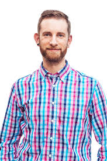

Hadley Wickham

### Python

OOP and functional language created by the Dutchman Guido van Rossum in 1991

[figure not shown]

Like R, it is also fully Open-source and multi-platform.It natively supports the powerful Selenium library which allows the creation of web browser automation bots.

### UIPath

Romanian firm founded in 2005 in Bucharest by Daniel Dines and Marius Tîrcă.

[figure not shown]

Closed-source, paying software (but a Community Edition is available), which uses Visual Programming. A classic example of what is called « RPA ». These tools allow to **spy** and interact with elements in an User Interface. An example video can be found [here](https://www.uipath.com/learning/video-tutorials/advanced-ui-automation).

Of course, all these tools (R, Python, UIPath) can be combined, to exploit each others’ capabilities in a hybrid solution. That’s what we will showcase later.

### Note: Python or R?

We think that R is best for scripting, as it is extremely flexible and allows to create scripts very quickly.

Some libraries such as Selenium are best used with python, natively (although R bindings exist with RSelenium).

R is mostly used with functional, rather than Object-oriented, programming, although [many R libraries](https://adv-r.hadley.nz/oo.html) allow to use OP in R. Their number makes the task somewhat harder than in python, since you need to know the specificities of the specific OOP paradigm you want to use. In python, a specific OOP implementation is available natively.

This is a classic example of the difference between those languages. Python imposses a relatively strict framework, and will error out more quickly than R when the behaviour of the program is unexpected. R allows for much more flexibility, and in many cases *guesses* what you’re trying to do, which can sometimes lead to a surprising behaviour. In addition, several R packages modify the base R syntax by overloading the base operators, so you have effectively several style of syntax you can use in R, depending on which packages you load. This is because R exposes a very high level of [metaprogramming](https://adv-r.hadley.nz/metaprogramming.html).

We think however that this is a worthwile price to pay for the huge degree of freedom and the quick development possibilities offered by R.

Small example of the difference in behaviour:

```python
# PYTHON
mycolumn = list(range(5)) #[0, 1, 2, 3, 4]

# implicit loop on a python list with list comprehension

[10/x for x in mycolumn] # ERROR: ZeroDivisionError: division by zero
```

Python throws an error when dividing by 0, whereas R returns `Inf`:

```r
# R
mycolumn = c(0:4)
# in R, many operations are vectorized natively

10/mycolumn # 10/0 = Inf
```

```
[1]       Inf 10.000000  5.000000  3.333333  2.500000
```

#### Note: pandas, python and R

As you’ve seen before, the lack of vectorization in python sometimes calls for more elaborate (*“pythonic”*) syntax to perform simple operations in python. Pandas is a predominant library available in python allowing to alleviate some of that overhead and allows to do in python some vectorized operations that natively exist in R. Its creator [Wes McKinney](https://wesmckinney.com/) recently [joined Posit](https://posit.co/blog/welcome-wes/).

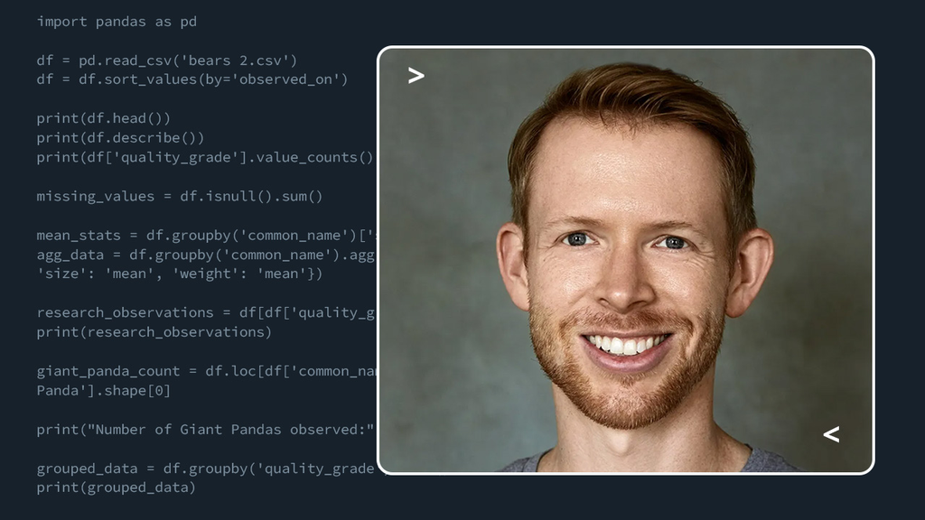

Wes McKinney, creator of the pandas library for python, recently joined Posit

On https://pandas.pydata.org/docs/getting_started/comparison/comparison_with_r.html we can find a syntax correspondence table between R and pandas.

> Since pandas aims to provide a lot of the data manipulation and analysis functionality that people use R for, this page was started to provide a more detailed look at the R language and its many third party libraries as they relate to pandas.

Enough for the introduction, let’s move on to the content.

## Programming for Excel users

Programming may not be any more complicated than using Excel functions. Let’s take examples in R:

### The SUMIF excel formula

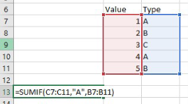

This is how this basic example could be done (you can think about it before unfolding):

in R:

```r
values <- 1:5
types <- c('A', 'B', 'C', 'A', 'B')

# summing where type == A
sum(values[types=='A']) # 5
```

```
[1] 5
```

This syntax is pretty much self-explanatory. Is it really more complicated than Excel formulas? Note the *vectorized* operations in R.

In Python:

```python
values = list(range(1,6)) # note the index difference vs R
types = ['A', 'B', 'C', 'A', 'B']

# summing where type == A
sum(val for val, t in zip(values, types) if t == 'A')
```

```
5
```

Note that by default python doesn’t have vectorized operations. We need to use a few more functions: - `(val for val, t in zip(values, types) if t == 'A')`: This is a generator expression. It produces the value val from each pair where the type (t) is equal to ‘A’. This generator expression generates values lazily, meaning it only computes the next value when it’s needed. - `zip(values, types)`: This function combines the elements of values and types into pairs. It pairs the first element of values with the first element of types, the second element of values with the second element of types, and so on.

This illustrates some differences between the two languages. There are often many ways to perform the same operation.

### The VLOOKUP excel formula

```r
# Sample data
df1 <- data.frame(ID = c(1, 2, 3, 4),
                  Name = c("Alice", "Bob", "Charlie", "David"))

df2 <- data.frame(ID = c(1, 2, 3, 4),
                  Score = c(85, 90, 75, 80))

# VLOOKUP in R
df1$Score <- df2$Score[match(df1$ID, df2$ID)]

#print(df1)
```

Try to use the above code into RStudio and examine the result `df1`.

```python
import pandas as pd

# Sample data
df1 = pd.DataFrame({'ID': [1, 2, 3, 4],
                    'Name': ['Alice', 'Bob', 'Charlie', 'David']})

df2 = pd.DataFrame({'ID': [1, 2, 3, 4],
                    'Score': [85, 90, 75, 80]})

# VLOOKUP in Python with pandas
df1['Score'] = df1['ID'].map(df2.set_index('ID')['Score'])

#print(df1)
```

In RStudio, create a new python script, execute the above code, and examine the result `df1`.

### Exercise 1: combining two files

Let’s see how we can explore data using scripts. In this first exercise, read 2 csv files as dataframes, and combine them togethen by appending the rows of the second one to the first one.

```r
a
```

```
    Name Age
1   Jack  22
2 George  30
3  David  54
4   Eric  27
5   Alex  45
```

```r
b
```

```
     Name Age
1 Michael  16
2  Robert  80
3   Janet  75
4   Diane  31
5 Gregory  20
```

- Go to https://github.com/gpierard/CatalystRPA_trainings_public and download the files `a.csv` and `b.csv`.
- Use Google to find a way to read this file in R or python, as you prefer.

**Tip**

stackoverflow.com and chatGPT can be very helpful.

Resolution (try yourself first)

In R:

```r
starttime <- Sys.time()
a <- read.csv(r"[G:\Shared drives\CatalystRPA\Clients\Technifutur\Cours 09-2021\Exercices\Exercice 2\Resolution\R\A.csv]")
b <- read.csv(r"[G:\Shared drives\CatalystRPA\Clients\Technifutur\Cours 09-2021\Exercices\Exercice 2\Resolution\R\B.csv]")
result <- rbind(a,b) # concatenating data from both files
result$double_age <- result$Age*2
endtime <- Sys.time()
endtime-starttime
print(result)
```

In Python:

```python
import pandas as pd

starttime = time.time()

# Read CSV files
a = pd.read_csv(r"G:\Shared drives\CatalystRPA\Clients\Technifutur\Cours 09-2021\Exercices\Exercice 2\Resolution\R\A.csv")
b = pd.read_csv(r"G:\Shared drives\CatalystRPA\Clients\Technifutur\Cours 09-2021\Exercices\Exercice 2\Resolution\R\B.csv")

# Concatenate dataframes
result = pd.concat([a, b], ignore_index=True)

# Create a new column 'double_age' by doubling the 'Age' column
result['double_age'] = result['Age'] * 2

endtime = time.time()

print(result)
```

### Exercise 2: Under the hood

This second example is a bit more complicated.

- Go to https://github.com/gpierard/CatalystRPA_trainings_public and download the file `cars.xlsx`
- Use Google to find a way to read this file in R or python, as you prefer.
- Part 1: Calculate the mean price of vehicles with at least 6 cylinders.
- Part 2: Calculate the mean price of vehicles with at least 6 cylinders and over 200HP.

Again, stackoverflow.com is a useful resource.

#### Resolution (in R) - try by yourself first:

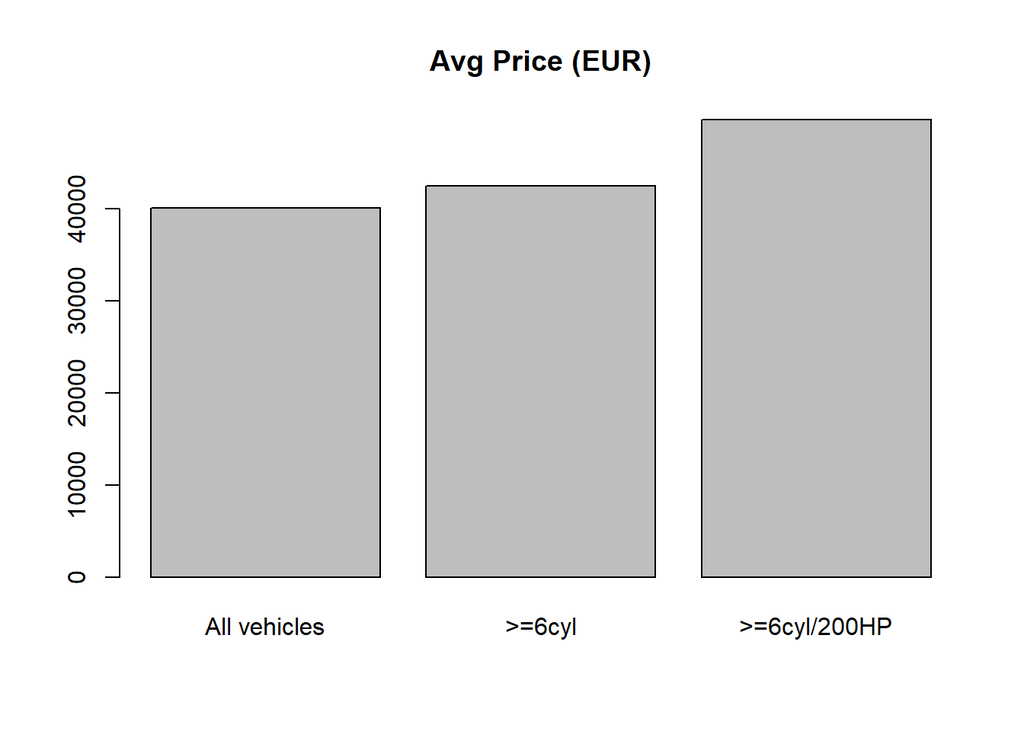

```r
library(openxlsx) # install.packages("openxlsx")
library(assertthat) # install.packages("assertthat")
df <- read.xlsx(r"{G:\Shared drives\CatalystRPA\Clients\Technifutur\Cours 09-2021\Exercices\Exercice 4\cars.xlsx}")
df$numprice <- gsub(" Euro", "", df$Base.price, ignore.case = T)
df$numprice <- as.numeric(df$numprice)

# assert_that(is.numeric(df$numprice), msg="error, the new price is not numeric")
# plot(df$numprice[order(df$numprice)])

# part 1 ------------------------------------------------------------------

myfilter <- df$Number.of.cylinders>=6
df2 <- df[myfilter,]
# nrow(df);ncol(df); dim(df2)
# class(df2)

meanprice1 <- mean(df2$numprice)
# print(meanprice1)


# part 2 ------------------------------------------------------------------

myfilter <- df$Number.of.cylinders>=6 & df$`Power.(HP)`>=200
meanprice2 <- mean(df$numprice[myfilter])
# print(meanprice2)

barplot(c(mean(df$numprice), meanprice1, meanprice2), main="Avg Price (EUR)", names.arg = c("All vehicles", ">=6cyl", ">=6cyl/200HP"))
```

#### Resolution in python

We can indeed perform the same kind of operations with pandas in python.

```
pip install pandas
```

```python
import pandas as pd

# Read the Excel file
df = pd.read_excel("G:/Shared drives/CatalystRPA/Clients/Technifutur/Cours 09-2021/Exercices/Exercice 4/cars.xlsx")

# Remove " Euro" from the 'Base.price' column and convert to numeric
df['numprice'] = df['Base price'].str.replace(' Euro', '').astype(float)

# Part 1
myfilter = df['Number of cylinders'] >= 6 # vectorized operations, as in R.
df2 = df[myfilter]

# Calculate the mean price
meanprice1 = df2['numprice'].mean()
# print(meanprice1)

# remainder is left for you to finish
```

As you can see, the pandas syntax in python is similar, and offers the same kind of capabilities than R, including vectorization.

# Browser automation in Python with Selenium

Now that we have some basic experience with R and Python, let’s dive into browser automation with a Selenium example and see how it actually works.

**Tip**

Selenium is best used with python.

Head to [Selenium - Getting Started](https://www.selenium.dev/documentation/webdriver/getting_started/) and install the python library.

`pip install selenium`

### Example

```python
from selenium import webdriver
from selenium.webdriver.common.by import By
from selenium.webdriver.common.keys import Keys
driver = webdriver.Chrome() # start the chrome driver
driver.implicitly_wait(1) # set an implicit wait time of 1 second
driver.maximize_window()

driver.get("https://www.google.com/?gl=us&hl=en&gws_rd=cr&pws=0")
```

In order to interact with the different elements, we can use Chrome DevTools

> Chrome DevTools is a set of web developer tools built directly into the Google Chrome browser. DevTools can help you edit pages on-the-fly and diagnose problems quickly, which ultimately helps you build better websites, faster.

Either right click on the element you need to interact with and select `inspect`, or use the `Ctrl+Shift+C` shortcut. Let’s try that on the google search bar.

[figure not shown]

Let’s zoom in on the elements.

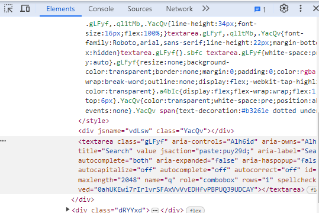

We see that an html tag of the search bar is `textarea`, and it has a `title` attribute with value `Search`. Let’s use that information back in our Selenium program.

```python
text_areas = driver.find_elements(By.TAG_NAME, "textarea")
len(text_areas) # 2
```

You can use a few methods to locate elements using `find_elements()` or `find_element()`. If the driver isn’t able to find any element matching your criteria after the (implicit or explicit) timeout defined, `find_elements()` will return an empty list, whereas `find_element()` will throw a timeout error. Here, we’ve found 2 elements with tag `textarea`. Let’s get the title attribute for those using python list comprehension syntax.

From the [python doc](https://docs.python.org/2/tutorial/datastructures.html)

> List comprehensions provide a concise way to create lists. Common applications are to make new lists where each element is the result of some operations applied to each member of another sequence or iterable, or to create a subsequence of those elements that satisfy a certain condition.

```python
titles = [x.get_attribute("title") for x in text_areas]
titles.index("Search") # 0
```

The results may differ for you, but I get that `titles` equals `['Search', '']`, meaning that only the first element in my list has the `Search` title. We can extract the corresponding index of this element using the `index` method of the list.

```python
searchbar = text_areas[titles.index("Search")]
searchbar.clear() # clear any previously entered text
searchbar.send_keys("CatalystRPA")
searchbar.send_keys(Keys.ENTER)
```

We’re now at the results page.

```python
driver.current_url #'https://www.google.com/search?q=CatalystRPA&sca_esv=9 ...
```

Let’s retrieve the first result and click it. Like before, we can inspect the result link.

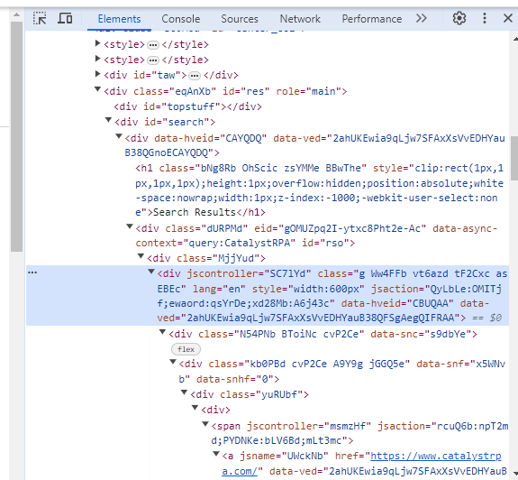

Here, it’s slightly more complicated as we don’t have meaningful class names, which means that these names can potentially change for each run of the robot. We do however have a parent `div` with `id="search"`

```python
# retrieve the parent searchresult element
searchresults = driver.find_elements(By.XPATH, "//div[@id='search']")
len(searchresults) # 1
searchres = searchresults[0]
```

Now that we’ve identified the parent element, we can narrow down our search. let’s examine the `href` attributes of `a` tags contained in the search results. We can see that the `href` of the first element contains the link we’re after.

```python
# check the first link of the results
allresults = searchres.find_elements(By.TAG_NAME, "a")
len(allresults) # 37
allresults[0].get_attribute('href') # 'https://www.catalystrpa.com/' this is the correct element, first search result
# however, this element is not clickable
```

Since that `a` element is not clickable, we can retrieve the first `h3` tag contained in `searchres`, and click it (of course we could have used the `href` URL directly with `driver.get(<url>`). There are often many ways to perform the same action, some more elegant than others. This is just an illustrative example.

```python
all_links = searchres.find_elements(By.TAG_NAME, "h3")
len(all_links) # 12

allresults = searchres.find_elements(By.TAG_NAME, "a")
links = [x.get_attribute('href') for x in allresults]
all_links[links.index('https://www.catalystrpa.com/')].click() # OK
driver.current_url # 'https://www.catalystrpa.com/ OK'
# we could continue...
```

### Exercise: Selenium

Click below to unfold the full script from the previous example, and use it as an example to create a similar python script in RStudio (or another IDE) using Selenium to find the website of your current organization on google and visit it.

```python
from selenium import webdriver
from selenium.webdriver.common.by import By
from selenium.webdriver.common.keys import Keys
driver = webdriver.Chrome() # start the chrome driver
driver.implicitly_wait(1) # set an implicit wait time of 1 second
driver.maximize_window()

driver.get("https://www.google.com/?gl=us&hl=en&gws_rd=cr&pws=0") # US website
text_areas = driver.find_elements(By.TAG_NAME, "textarea")
len(text_areas)
titles = [x.get_attribute("title") for x in text_areas]

searchbar = text_areas[titles.index("Search")]
searchbar.clear() # clear any previously entered text
searchbar.send_keys("CatalystRPA")
searchbar.send_keys(Keys.ENTER)
driver.current_url

# there are many div elements on the page
div_elements = driver.find_elements(By.TAG_NAME, "div")
len(div_elements) # 1251

# retrieve the parent searchresult element
searchresults = driver.find_elements(By.XPATH, "//div[@id='search']")
len(searchresults) # 1
searchres = searchresults[0]

# check the first link of the results
allresults = searchres.find_elements(By.TAG_NAME, "a")
len(allresults) # 37
allresults[0].get_attribute('href') # 'https://www.catalystrpa.com/' this is the correct element, first search result
# however, this element is not clickable

all_links = searchres.find_elements(By.TAG_NAME, "h3")
len(all_links) # 12
all_links[0].click() # OK

driver.current_url # 'https://www.catalystrpa.com/'
# we could continue...
```

## Combining tools

There are several ways to combine UIPath robots, R and python scripts. For example, we can use `system` in R to send system commands, or we can use the terminal directly.

```
system("python myscript.py")
```

To launch an R script from python, use

```
subprocess.call ("/pathto/MyrScript.r")
```

To execute an UIPath sequence, we can use the UIRobot utility.

```
"C:\Users\{UserName}\AppData\Local\UiPath\app-20.4.1-beta0022\UiRobot.exe" "C:\UiPath\Automation\Main.xaml"
```